# TON-USD

## TON-USD today is +0200, 2025-10-30, 21:40:48

This crypto forecast was generated by gemini-2.0-flash API

## Daily Chart

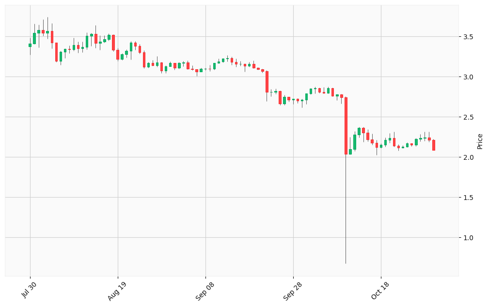

## Hourly Chart

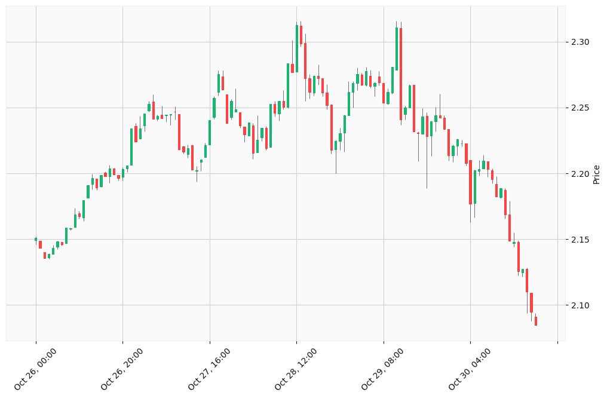

Okay, I will analyze the provided TON-USD cryptocurrency data using the specified steps and output format to generate trading signals. Given the time-sensitive nature of market analysis, I will use the Google Search tool to gather the most current information available.

First, I need to get some information about the global market, news and economic factors.

Based on the search results:

- **Overall Market**: The global cryptocurrency market cap is around $3.68 trillion, a decrease from the previous day.
- **Recent Performance:** The crypto market is down today. Bitcoin is around $108,060 - $109,373, and Ethereum is around $3,786 - $3,868.
- **Macroeconomic Factors**:
  - **Inflation and Interest Rates:** Lower inflation often leads to interest rate cuts, increasing liquidity for cryptocurrencies. If inflation remains high, it could lead to contractionary expectations and price declines. The US Federal Reserve’s recent rate cut sent Bitcoin briefly down, but the end of quantitative tightening could fuel risk assets.
  - **Economic Growth**: Economic expansion typically increases investment in assets like Bitcoin, while recessions may lead investors to liquidate riskier assets.
  - **Geopolitical Events**: Geopolitical events can trigger a rush toward Bitcoin, causing price spikes.
- **News**:
  - A meeting between U.S. and Chinese leaders and cautious comments from the Federal Reserve are influencing the market.
  - Hong Kong is tightening its watch on crypto treasuries.
  - There are developments regarding Solana ETFs.

Now, I will proceed with the technical analysis of the provided TON-USD data.

**Technical Analysis**

I will analyze the daily and hourly charts to identify potential buy and sell signals, using technical indicators and trend analysis.

**Daily Chart Analysis (Last Three Months)**

First, let’s calculate some basic indicators from the daily chart data: